# Homework 2 - Mateus_D_Souza

## d) Derive the functional form (up to proportionality constants) of all full-conditionals

```
  For deriving the full conditions, we will jump over the non stochastic node Mu_i.
  Here are the full conditions of the priors:
```

$$P(\mu_{i}|\alpha,\beta,\gamma,\tau^{2},Y_{i},x_{i}) \propto P(\mu_{i}|\alpha,\beta,\gamma,x_{i})
\\
P(\mu_{i}|\alpha,\beta,\gamma,\tau^{2},Y_{i},x_{i}) \propto (\alpha - \beta\gamma^{x_{i}})$$
$$P(\tau^{2}|\alpha,\beta,\gamma,\mu_{i},Y_{i},x_{i}) \propto P(\tau^{2}).P(Y_{i}|\mu_{i},\tau^{2})
\\
P(\tau^{2}|\alpha,\beta,\gamma,\mu_{i},Y_{i},x_{i}) \propto IG(a,b).N(\mu_{i},\tau^{2})$$
$$P(\alpha|\mu_{i},\beta,\gamma,\tau^{2},Y_{i},x_{i}) \propto P(\alpha).P(Y_{i}|\alpha,\beta,\gamma,\tau^{2})
\\
P(\alpha|\mu_{i},\beta,\gamma,\tau^{2},Y_{i},x_{i}) \propto N(0,\sigma^{2}_{\alpha}).N(\mu_{i},\tau^{2})$$
$$P(\beta|\mu_{i},\alpha,\gamma,\tau^{2},Y_{i},x_{i}) \propto P(\beta).P(Y_{i}|\alpha,\beta,\gamma,\tau^{2})
\\
P(\beta|\mu_{i},\alpha,\gamma,\tau^{2},Y_{i},x_{i}) \propto N(0,\sigma^{2}_{\beta}).N(\mu_{i},\tau^{2})$$
$$P(\gamma|\mu_{i},\alpha,\beta,\tau^{2},Y_{i},x_{i}) \propto P(\gamma).P(Y_{i}|\alpha,\beta,\gamma,\tau^{2})
\\
P(\gamma|\mu_{i},\alpha,\beta,\tau^{2},Y_{i},x_{i}) \propto Unif(0,1).N(\mu_{i},\tau^{2})$$

## e) Which distribution can you recognize within standard parametric families so that direct simulation from full conditional can be easily implemented ?

[output not shown]

## f) Using a suitable Metropolis-within-Gibbs algorithm simulate a Markov chain (T = 10000) to approximate the posterior distribution for the above model

```r
#initialize the hyperparameters
a <-3
b <-5
sd_alpha <-1
sd_beta <-1
#--------------------

#initialize the parameters for the Gibbs Sampling
mu_i.0 <-c(replicate(27,sum(df$length)/length(df$length)))
tau_2.0<-var(df$length)
alpha.0 <- 0.1
beta.0 <-0.01
gamma.0 <-0.05
#-------------------

#--------------------
present.mu_i <-mu_i.0
present.tau_2 <-tau_2.0
present.alpha <-alpha.0
present.beta <-beta.0
present.gamma <-gamma.0
#--------------------

#vector to save the update of the parameters
mu_sim <-rbind(present.mu_i)
tau_2_sim<-c(present.tau_2)
alpha_sim<-c(present.alpha)
beta_sim<-c(present.beta)
gamma_sim<-c(present.gamma)
#------------------

like<- function(y,mu,tau){
  n<-length(y)
  var<-1
  for(i in 1:n){
    var<-var*dnorm(y[i],mean = mu[i],sd=sqrt(tau))
  }
  return(var)
}

likelihood<-like(df$length,present.mu_i,present.tau_2)
#start the simulations with T=10000
nsim <-10000
update.mu_i<-present.mu_i
update.alpha<-present.alpha
update.beta<-present.beta
update.gamma<-present.gamma
update.tau2<-present.tau_2
for(t in 1:nsim){
  update.tau2<-rinvgamma(1, a, b)*likelihood
  update.alpha<-rnorm(1,mean=0,sd=sqrt(sd_alpha))*likelihood
  update.beta<-rnorm(1,mean=0,sd=sqrt(sd_beta))*likelihood
  update.gamma <-runif(1,0,1)*likelihood
  for(i in 1:27){
    update.mu_i[i] <- update.alpha-update.beta*update.gamma^(df$age[i])
  }
  present.mu_i<-update.mu_i
  present.tau_2<-update.tau2
  present.alpha<-update.alpha
  present.beta<-update.beta
  present.gamma<-update.gamma


  mu_sim <-rbind(mu_sim,present.mu_i)
  tau_2_sim<-c(tau_2_sim,present.tau_2)
  alpha_sim<-c(alpha_sim,present.alpha)
  beta_sim<-c(beta_sim,present.beta)
  gamma_sim<-c(gamma_sim,present.gamma)
}
```

## g) Show the 4 univariate trace-plots of the simulations of each parameter

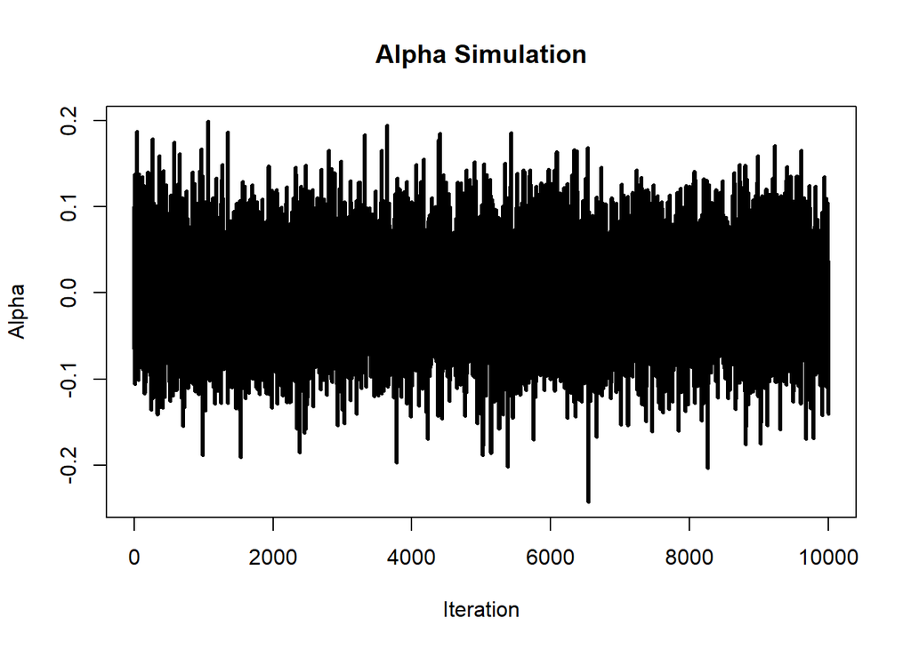

```r
plot(alpha_sim,type='l',lwd=3,main='Alpha Simulation',ylab = 'Alpha',xlab = 'Iteration')
```

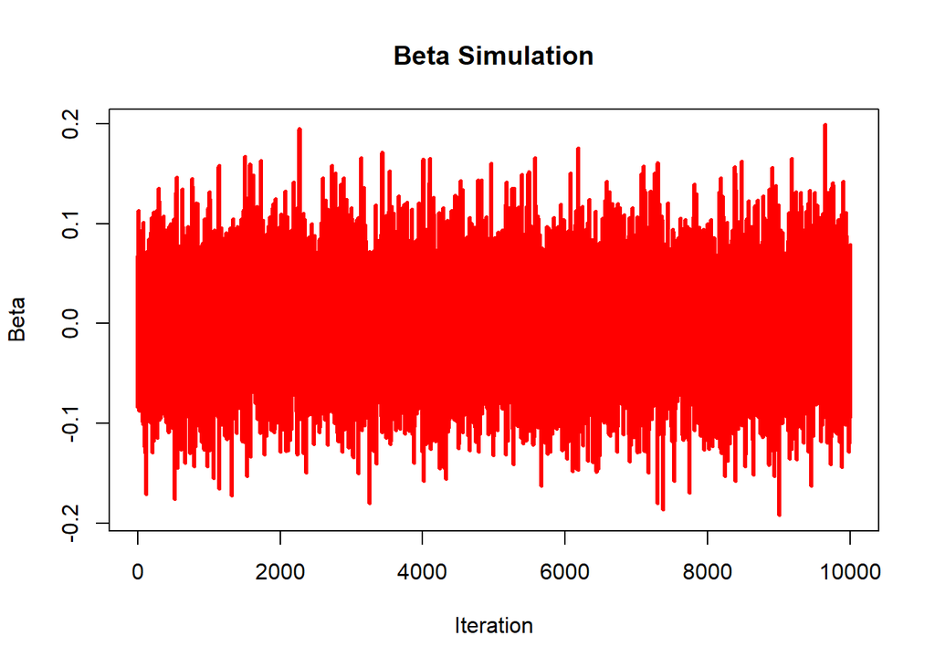

```r
plot(beta_sim,type='l',lwd=3,col='red',main='Beta Simulation',ylab = 'Beta',xlab = 'Iteration')
```

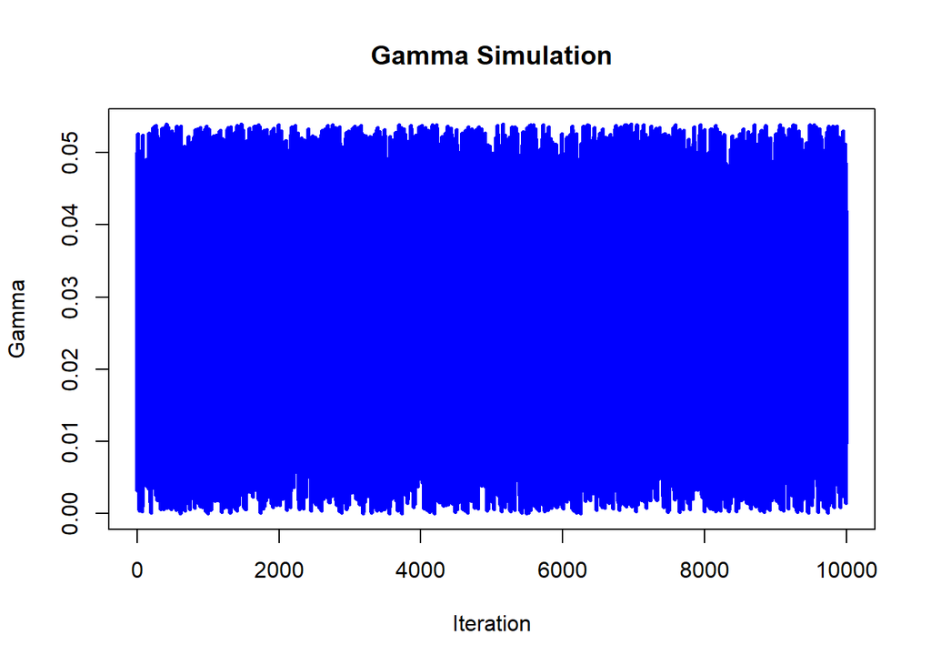

```r
plot(gamma_sim,type='l',lwd=3,col='blue',main='Gamma Simulation',ylab = 'Gamma',xlab = 'Iteration')
```

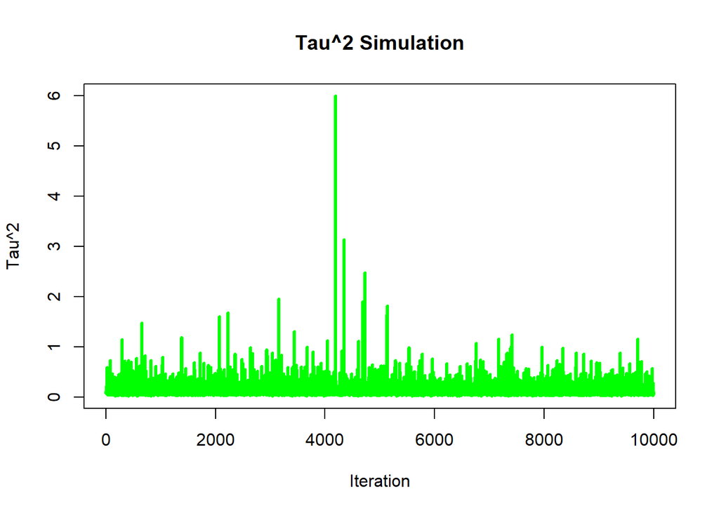

```r
plot(tau_2_sim,type='l',lwd=3,col='green',main='Tau^2 Simulation',ylab = 'Tau^2',xlab = 'Iteration')
```

## h) Evaluate graphically the behaviour of the empirical averages ˆIt with growing t = 1, …, T

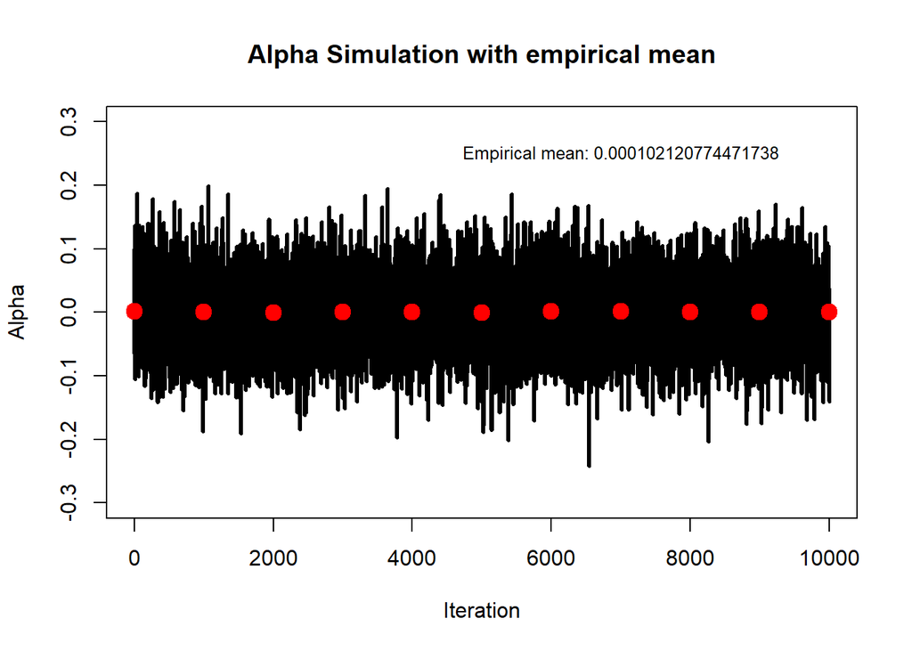

```r
alpha_eval<-rep(0,11)
#-----------------------------
for(i in 1:10){
  samp<-alpha_sim[1:1000*i]
  alpha_eval[i] <-sum(samp)/length(samp)
}

plot(alpha_sim,type='l',lwd=3,main='Alpha Simulation with empirical mean',ylab = 'Alpha',xlab = 'Iteration',ylim=c(-0.3,0.3))
par(new=TRUE)
plot(alpha_eval,pch=19,lwd=6,col='red',axes=FALSE,xlab = '',ylab = '',ylim=c(-0.3,0.3))
text(8,0.25,paste('Empirical mean:',mean(alpha_sim)),cex=0.8)
```

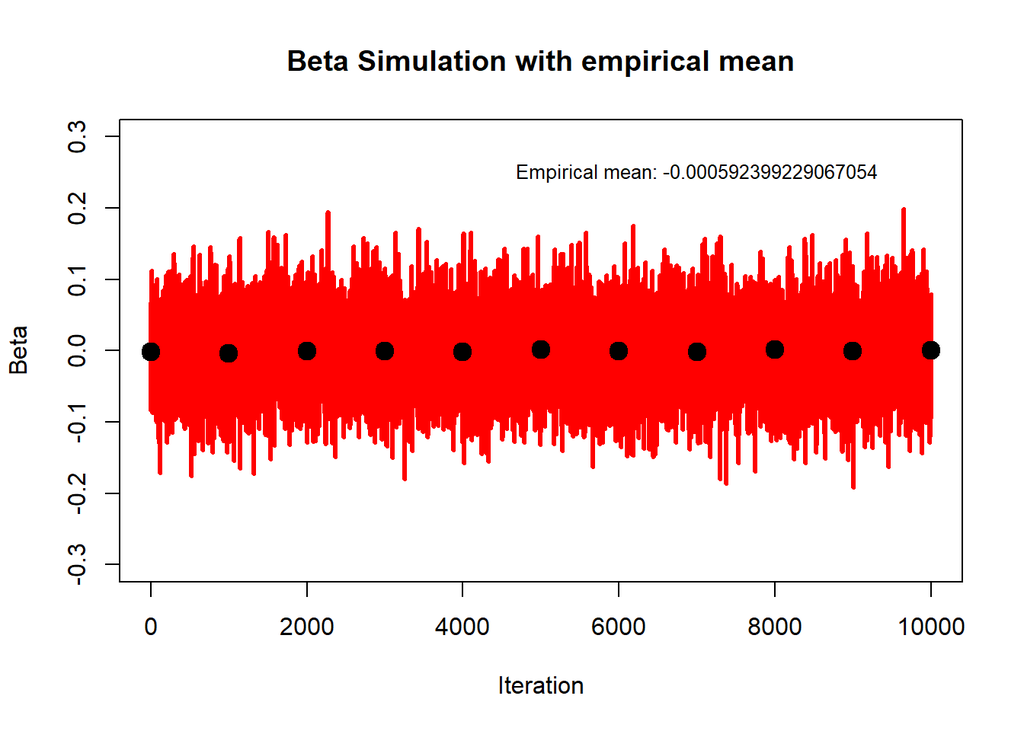

```r
beta_eval<-rep(0,11)
#-----------------------------
for(i in 1:10){
  samp<-beta_sim[1:1000*i]
  beta_eval[i] <-sum(samp)/length(samp)
}

plot(beta_sim,type='l',lwd=3,main='Beta Simulation with empirical mean',ylab = 'Beta',xlab = 'Iteration',col='red',ylim=c(-0.3,0.3))
par(new=TRUE)
plot(beta_eval,pch=19,lwd=6,col='black',axes=FALSE,xlab = '',ylab = '',ylim=c(-0.3,0.3))
text(8,0.25,paste('Empirical mean:',mean(beta_sim)),cex=0.8)
```

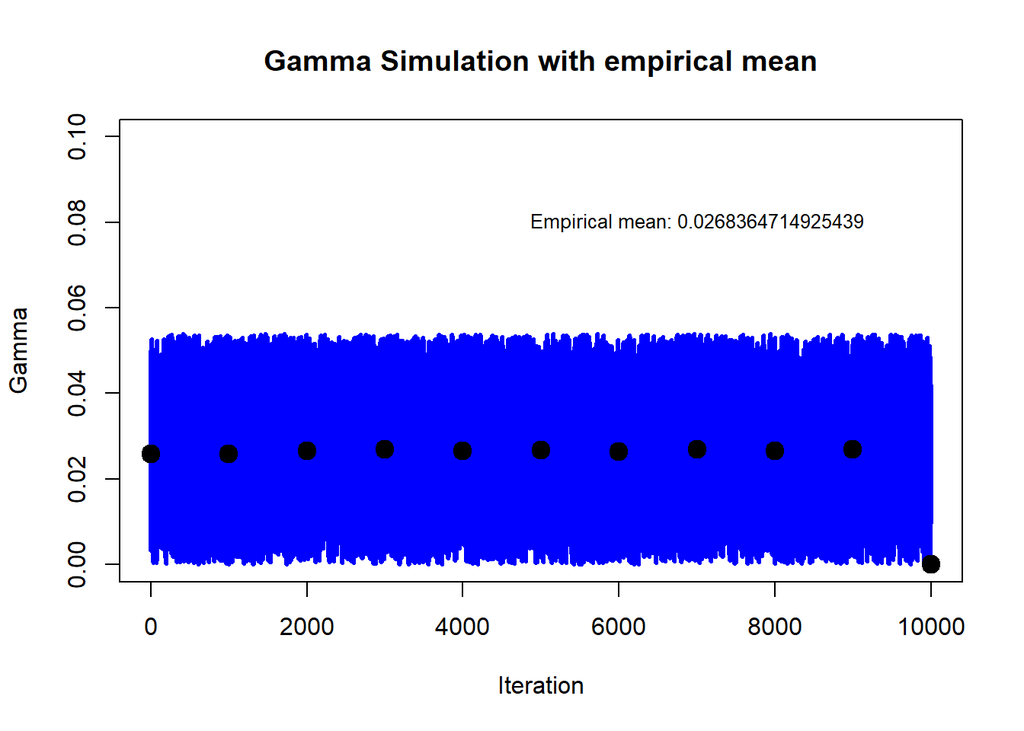

```r
gamma_eval<-rep(0,11)
#-----------------------------
for(i in 1:10){
  samp<-gamma_sim[1:1000*i]
  gamma_eval[i] <-sum(samp)/length(samp)
}

plot(gamma_sim,type='l',lwd=3,main='Gamma Simulation with empirical mean',ylab = 'Gamma',xlab = 'Iteration',col='blue',ylim = c(0,0.1))
par(new=TRUE)
plot(gamma_eval,pch=19,lwd=6,col='black',axes=FALSE,xlab = '',ylab = '',ylim=c(0,0.1))
text(8,0.08,paste('Empirical mean:',mean(gamma_sim)),cex=0.8)
```

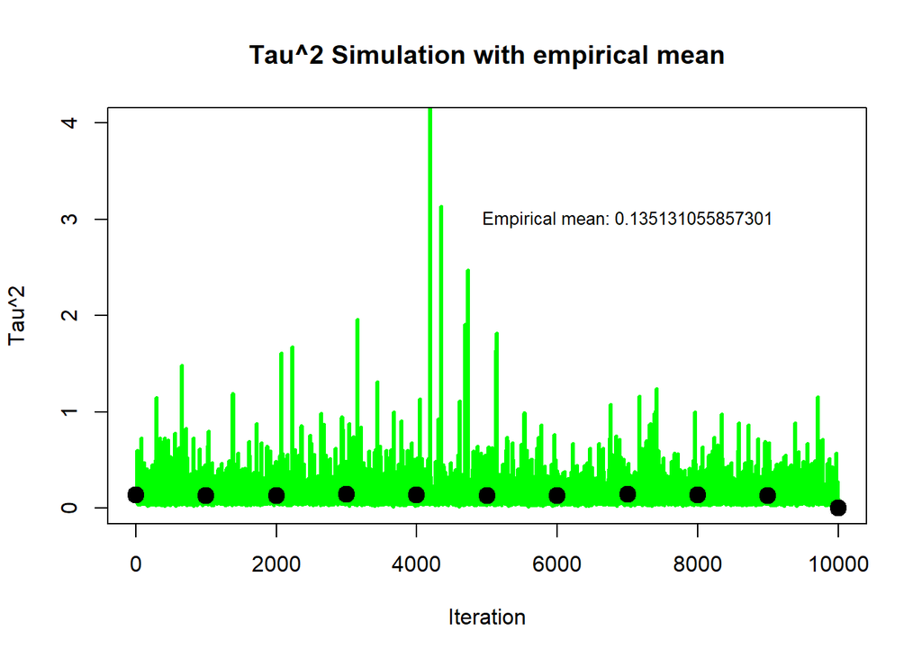

```r
tau_2_eval<-rep(0,11)
#-----------------------------
for(i in 1:10){
  samp<-tau_2_sim[1:1000*i]
  tau_2_eval[i] <-sum(samp)/length(samp)
}

plot(tau_2_sim,type='l',lwd=3,main='Tau^2 Simulation with empirical mean',ylab = 'Tau^2',xlab = 'Iteration',col='green',ylim=c(0,4))
par(new=TRUE)
plot(tau_2_eval,pch=19,lwd=6,col='black',axes=FALSE,xlab = '',ylab = '',ylim=c(0,4))
text(8,3,paste('Empirical mean:',mean(tau_2_sim)),cex=0.8)
```

## i) Provide estimates for each parameter together with the approximation error and explain how you have evaluated such error

As we are dealing with a Monte Carlo Simulation, the approximation error is unbiased and represented as a random variable of a normal distribution. So, when evaluating error of a Monte Carlo Simulation it is important to evaluate also the number of simulations because it has an effect of the approximation error and not a simple standart deviation. For this reason we use the already made method to evaluate the error, provided by the library “LaplaceDemons”.

For the parameter alpha he have the following estimation and error:

```r
alpha_emp <-mean(alpha_sim)
print(paste('Empirical mean of the parameter alpha:',alpha_emp))
```

```
## [1] "Empirical mean of the parameter alpha: 0.000102120774471738"
```

```r
print(paste('Approximation error for the estimation of the parameter alpha:',LaplacesDemon::MCSE(alpha_sim)))
```

```
## [1] "Approximation error for the estimation of the parameter alpha: 0.000569233182309654"
```

For the parameter beta he have the following estimation and error:

```r
beta_emp <-mean(beta_sim)
print(paste('Empirical mean of the parameter beta:',beta_emp))
```

```
## [1] "Empirical mean of the parameter beta: -0.000592399229067054"
```

```r
print(paste('Approximation error for the estimation of the parameter beta:',LaplacesDemon::MCSE(beta_sim)))
```

```
## [1] "Approximation error for the estimation of the parameter beta: 0.000519995772355988"
```

For the parameter gamma he have the following estimation and error:

```r
gamma_emp <-mean(gamma_sim)
print(paste('Empirical mean of the parameter gamma:',gamma_emp))
```

```
## [1] "Empirical mean of the parameter gamma: 0.0268364714925439"
```

```r
print(paste('Approximation error for the estimation of the parameter gamma:',LaplacesDemon::MCSE(gamma_sim)))
```

```
## [1] "Approximation error for the estimation of the parameter gamma: 0.000159150219944799"
```

For the parameter tau^2 he have the following estimation and error:

```r
tau_2_emp <-mean(tau_2_sim)
print(paste('Empirical mean of the parameter tau^2:',tau_2_emp))
```

```
## [1] "Empirical mean of the parameter tau^2: 0.135131055857301"
```

```r
print(paste('Approximation error for the estimation of the parameter tau^2:',LaplacesDemon::MCSE(tau_2_sim)))
```

```
## [1] "Approximation error for the estimation of the parameter tau^2: 0.00135571113910478"
```

## l) Which parameter has the largest posterior uncertainty? How did you measure it?

By comparison, the parameter with the largest posterior uncertainty by Monte Carlo Standard Error calculation, is the parameter tau^2, with 0.0013557.

## m) Which couple of parameters has the largest correlation (in absolute value)?

```r
print(paste('Correlation between alpha and beta:',abs(cor(alpha_sim,beta_sim))))
```

```
## [1] "Correlation between alpha and beta: 0.000811829617807366"
```

```r
print(paste('Correlation between alpha and gamma:',abs(cor(alpha_sim,gamma_sim))))
```

```
## [1] "Correlation between alpha and gamma: 0.00508775992267996"
```

```r
print(paste('Correlation between alpha and tau^2:',abs(cor(alpha_sim,tau_2_sim))))
```

```
## [1] "Correlation between alpha and tau^2: 0.0017883034514977"
```

```r
print(paste('Correlation between gamma and tau^2:',abs(cor(gamma_sim,tau_2_sim))))
```

```
## [1] "Correlation between gamma and tau^2: 0.0210885263258592"
```

```r
print(paste('Correlation between beta and tau^2:',abs(cor(beta_sim,tau_2_sim))))
```

```
## [1] "Correlation between beta and tau^2: 0.000776308797484037"
```

```r
print(paste('Correlation between beta and gamma^2:',abs(cor(beta_sim,gamma_sim))))
```

```
## [1] "Correlation between beta and gamma^2: 0.0212506454361771"
```

## n) Use the Markov chain to approximate the posterior predictive distribution of the length of a dugong with age of 20 years.

```r
x=20;
mu=alpha_emp-beta_emp*(gamma_emp^x)
y <-rnorm(1,mean = mu, sd=sqrt(1/tau_2_emp))
abs(y)
```

```
## [1] 0.1687178
```

## o) Provide the prediction of a different dugong with age 30

```r
x=30;
mu=alpha_emp-beta_emp*(gamma_emp^x)
y <-rnorm(1,mean = mu, sd=sqrt(1/tau_2_emp))
abs(y)
```

```
## [1] 0.2881873
```

## p) Which prediction is less precise?

According to the data we have, the prediction of the dugong with age of 20 years is less precise (differs more from the empirical mean of the data).

# Homework - Part 2

## a) Starting at time t = 0 in the state X0 = 1 simulate the Markov chain with distribution assigned as above for t = 1000 consecutive times

```
  Define the transition matrix and starting point, then do the markov chain simulations:
```

```r
#--------------------------
space_state<-c(1,2,3)
tpm<-matrix(c(0,1/2,1/2,5/8,1/8,1/4,2/3,1/3,0),nrow=3,byrow=TRUE)
x1<-1
#--------------------------

nsample<-1000
chain<-rep(NA,nsample+1)
chain[1]<-x1
#------------------------

for(t in 1:nsample){
  chain[t+1]<-sample(space_state,size=1,prob=tpm[chain[t],])
}
#-----------------------
print(chain)
```

```
##    [1] 1 2 1 2 3 2 3 1 3 1 2 1 2 2 1 2 3 1 2 1 3 1 3 1 2 3 1 2 2 1 2 3 1 2 1 3 2
##   [38] 1 3 1 2 3 2 2 1 2 1 2 3 1 2 1 2 3 1 2 1 2 2 3 1 3 2 1 3 1 2 1 3 2 1 2 3 1
##   [75] 2 1 2 1 2 3 2 3 2 1 2 1 2 3 1 3 1 2 1 3 1 2 2 1 2 2 1 2 1 2 1 3 2 3 2 1 3
##  [112] 2 1 3 2 1 2 1 3 1 2 1 3 1 2 1 3 1 3 1 2 3 2 1 2 3 1 3 2 2 1 2 1 3 1 3 1 3
##  [149] 1 2 1 3 2 1 2 1 3 1 2 3 1 2 2 1 3 2 2 1 3 1 2 1 2 2 1 3 2 2 1 3 2 3 1 3 1
##  [186] 3 1 2 3 2 3 1 3 2 1 2 3 1 3 1 2 1 3 2 1 3 2 1 2 3 2 1 2 3 1 3 2 2 1 2 3 1
##  [223] 3 1 3 1 2 1 3 1 3 1 2 1 3 1 2 1 2 3 2 1 3 1 2 1 2 3 2 3 1 3 1 2 1 3 1 3 1
##  [260] 2 2 3 1 2 3 1 3 1 2 1 2 1 3 1 3 1 2 1 3 2 2 2 3 2 2 1 3 1 2 1 2 1 3 2 1 2
##  [297] 1 3 1 2 3 2 1 3 1 3 1 2 1 2 3 1 2 1 3 1 2 1 3 2 1 3 1 3 1 2 1 2 1 3 1 2 1
##  [334] 2 3 1 3 1 3 1 3 2 1 3 1 3 1 2 3 1 3 2 3 2 1 3 1 2 1 3 1 3 1 2 3 1 3 1 3 1
##  [371] 2 1 3 1 2 1 3 1 2 1 3 1 3 1 3 2 1 3 2 3 1 3 1 3 1 3 1 2 1 2 1 3 2 1 2 1 3
##  [408] 1 3 2 3 1 2 1 3 1 2 1 3 2 1 2 3 2 2 3 1 3 1 2 3 1 2 1 3 2 1 2 1 3 1 2 1 3
##  [445] 1 2 1 2 3 1 2 1 2 1 2 1 3 1 2 3 1 3 1 3 1 2 1 2 1 3 1 3 2 1 2 1 2 2 1 3 1
##  [482] 2 3 1 2 3 1 3 2 1 2 1 3 2 1 2 1 3 1 3 1 2 1 2 1 2 3 1 2 1 3 1 2 1 2 3 2 1
##  [519] 3 1 3 1 3 2 1 3 1 2 3 2 1 3 1 3 1 2 1 2 1 3 2 3 2 1 3 1 2 2 1 2 1 2 1 3 1
##  [556] 2 3 1 2 1 2 3 2 1 3 2 1 3 1 3 1 2 1 2 1 3 1 2 1 3 1 3 1 3 2 1 2 1 3 2 1 3
##  [593] 1 2 1 3 1 2 2 1 2 1 3 1 3 1 2 3 2 1 2 3 2 3 1 3 1 2 1 3 1 3 1 2 1 2 1 3 2
##  [630] 1 2 1 3 1 2 1 3 1 2 1 3 2 3 1 2 1 3 2 1 2 1 3 1 3 1 3 2 3 2 1 3 1 2 2 1 2
##  [667] 1 3 2 1 2 3 2 1 2 1 3 1 2 2 3 1 2 1 3 1 3 1 2 1 3 1 2 1 3 2 1 2 1 2 1 3 1
##  [704] 3 1 2 1 2 1 2 3 1 3 1 3 2 3 2 3 1 2 1 3 1 2 1 3 2 1 3 1 2 1 2 3 1 2 1 3 1
##  [741] 2 3 1 3 1 3 1 2 1 3 1 3 1 2 1 2 1 3 1 2 2 1 2 1 2 1 3 2 1 3 1 3 2 1 3 2 3
##  [778] 1 3 1 2 1 2 2 1 2 3 2 1 2 1 2 3 1 3 1 3 1 3 1 3 1 2 1 2 2 1 3 1 2 2 1 3 1
##  [815] 3 1 3 1 2 3 1 3 2 1 3 1 3 1 3 2 2 3 2 2 1 3 1 2 1 3 1 3 1 3 1 3 1 3 1 3 1
##  [852] 3 1 3 2 2 1 2 1 3 2 2 2 1 2 2 3 1 2 1 3 1 2 1 2 1 2 3 1 2 1 3 1 2 1 3 1 3
##  [889] 1 3 2 1 2 1 2 3 2 1 2 1 3 2 1 3 1 3 1 3 2 1 3 1 2 1 2 1 2 1 3 2 2 1 2 1 2
##  [926] 3 1 3 1 3 1 3 2 3 2 1 2 1 3 1 3 1 2 3 1 3 1 3 1 2 1 2 1 2 1 3 2 3 2 2 3 1
##  [963] 2 2 1 2 3 1 2 1 2 3 1 3 2 1 3 2 1 2 3 1 3 1 3 2 1 3 1 3 1 2 1 2 3 1 2 1 2
## [1000] 1 2
```

## b) compute the empirical relative frequency of the states in your simulation

```r
result_b<- prop.table(table(chain))
result_b
```

```
## chain
##         1         2         3
## 0.3996004 0.3196803 0.2807193
```

## c) repeat the simulation for 500 times and record only the final state at time t = 1000 for each of the 500 simulated chains. Compute the relative frequency of the 500 final states. What distribution are you approximating in this way? Try to formalize the difference between this point and the previous point.

```r
nsample<-1000
cha<-x1
chain_2<-rep(NA,500)
for(h in 1:500){
for(t in 1:nsample){
  cha <-sample(space_state,size=1,prob=tpm[cha,])
}
chain_2[h]<-cha
  }
result_c<- prop.table(table(chain_2))
result_c
```

```
## chain_2
##     1     2     3
## 0.368 0.376 0.256
```

[output not shown]

## d) compute the theoretical stationary distribution and explain how you have obtained it

```
  The theoretical stationary distribution is obtained by the normalized eigen vectors corresponding to the eigen value lambda =1 of the transition probability matrix of the steady-state.
```

```r
pi_star <- eigen(t(tpm))$vector[,1]/sum(eigen(t(tpm))$vector[,1])
pi_star
```

```
## [1] 0.3917526 0.3298969 0.2783505
```

## e) Is it well approximated by the simulated empirical relative frequencies computed in (b) and (c)?

```
  Here bellow we can see that the result is well approximated in respect to what was computed in (b) and (c).
```

```r
result_b
```

```
## chain
##         1         2         3
## 0.3996004 0.3196803 0.2807193
```

```r
result_c
```

```
## chain_2
##     1     2     3
## 0.368 0.376 0.256
```

```r
pi_star
```

```
## [1] 0.3917526 0.3298969 0.2783505
```

## f) what happens if we start at t = 0 from state X0 = 2 instead of X0 = 1?

```r
#--------------------------
x1<-2
#--------------------------
nsample<-1000
chain_f<-rep(NA,nsample+1)
chain_f[1]<-x1
#------------------------

for(t in 1:nsample){
  chain_f[t+1]<-sample(space_state,size=1,prob=tpm[chain_f[t],])
}
#-----------------------
result_f1<- prop.table(table(chain_f))
#-------------------------
nsample<-1000
cha_f<-x1
chain_2_f<-rep(NA,500)
for(h in 1:500){
for(t in 1:nsample){
  cha_f <-sample(space_state,size=1,prob=tpm[cha_f,])
}
chain_2_f[h]<-cha_f
}
#------------------------------------------
result_f2<- prop.table(table(chain_2_f))
#------------------------------------------
result_f1
```

```
## chain_f
##         1         2         3
## 0.3976024 0.3256743 0.2767233
```

```r
result_f2
```

```
## chain_2_f
##     1     2     3
## 0.408 0.300 0.292
```

```r
pi_star
```

```
## [1] 0.3917526 0.3298969 0.2783505
```

```
  By changing the starting point of the steady-state in the markov chain, the result still converge to the same distribution of the states as we can see by the results above.
```